# Quantified Self Movement Analysis

## Required Libraries

```r
library(ggplot2)
library(caret)
```

## Data Processing

The raw dataset was split into an 70/30 training/testing dataset. Our final validation datset is only 20 entries, and will be used for a wrap-up summarization.

```r
raw_data <- read.csv("./data/pml-training.csv")
final_validation <- read.csv("./data/pml-testing.csv")

set.seed(343434)
inTrain <- createDataPartition(raw_data$classe, p=.7, list=FALSE)
training <- raw_data[inTrain,]
testing <- raw_data[-inTrain,]
```

## Exploration

We need to explore some critical elements to our data.

```r
summary(training)
```

[output not shown]

First - our observations must be well represented across all classe groups.

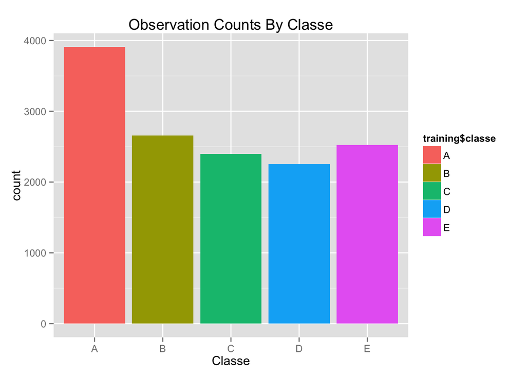

```r
classePlot <- qplot(training$classe, fill=training$classe)
classePlot + labs(title="Observation Counts By Classe") + xlab("Classe")
```

## Feature Selection

```r
# Remove Near Zero Variance data
nzv <- nearZeroVar(training)
training.filtered <- training[, -nzv]

most_pop<-apply(!is.na(training.filtered),2,sum)>(nrow(training.filtered) * .95)
training.filtered<-training.filtered[,most_pop]

# remove columns that are not related directly to sensors
training.filtered <- training.filtered[, -(1:5)]
```

Results:  
* Near Zero Variance test reduced features from 160 to 108  
* NA column removal (95% threshold) reduced features from 108 to 59  
* Non Applicable column removal took us from 59 columns to 54

```r
#The columns removed as they did not apply were
names(training[,1:5])
```

```
## [1] "X"                    "user_name"            "raw_timestamp_part_1"
## [4] "raw_timestamp_part_2" "cvtd_timestamp"
```

## Model Creation

```r
set.seed(123123)
trainCtl <- trainControl(
              method="cv"
              , number=5
              , classProbs = TRUE
            )

dtreeModel  <- train(classe ~ ., data=training.filtered, method="rpart", trControl=trainCtl)
gbmModel    <- train(classe ~ ., data=training.filtered, method="gbm", trControl=trainCtl)
```

We start off model creation by performing 2 different methodologies: a decision tree, and a generalized boosted model.

Our cross validation methodology will use k-fold methodology, setting the value of k to 5.

```r
gbm.predictions <- predict(gbmModel, newdata=testing)
dtree.predictions <- predict(dtreeModel, newdata=testing)
gbm.results <- confusionMatrix(testing$classe, gbm.predictions)
dtree.results <- confusionMatrix(testing$classe, dtree.predictions)
```

Our GBM model accuracy was 98.98%. Our decision tree model accuracy was 49.06%.

The GBM is the clear winner of these two. Diving further into the performance - the lower bounds of accuracy for our 95% Confidence Interval is 98.69%, and an upper bound of 99.22%.

For out of sample errors, we can be confident in our prediction being 98% accurate.

## Variable Importance

Now that we have a model, diving into variable importance to see what our highest predictors offered us:

```r
varImp(gbmModel)
```

```
## gbm variable importance
##
##   only 20 most important variables shown (out of 53)
##
##                   Overall
## roll_belt         100.000
## num_window         97.858
## pitch_forearm      46.292
## magnet_dumbbell_z  34.573
## yaw_belt           26.627
## magnet_dumbbell_y  24.314
## roll_forearm       23.525
## magnet_belt_z      15.189
## accel_forearm_x    15.012
## pitch_belt         14.751
## accel_dumbbell_z   12.430
## gyros_dumbbell_y   11.644
## roll_dumbbell      10.901
## gyros_belt_z       10.224
## accel_dumbbell_y    9.336
## accel_dumbbell_x    7.170
## accel_forearm_z     7.155
## yaw_arm             7.129
## magnet_forearm_z    7.065
## magnet_belt_y       4.749
```

Roll Belt was the most important variable, along with num window. Let’s visualize those quickly:

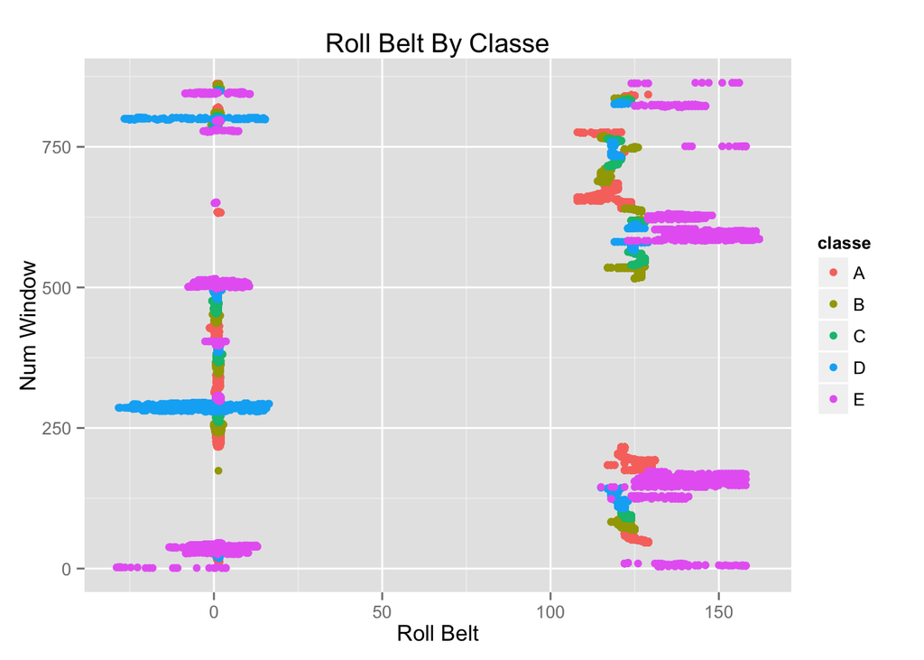

```r
roll_belt_plot <- qplot(x=roll_belt, y=num_window, data=training.filtered, colour=classe, fill=classe)
roll_belt_plot + labs(title="Roll Belt By Classe") + xlab("Roll Belt") + ylab("Num Window")
```